# Econometry Group Work - Emma BOURDIT & Olivier CARON

### I - OLS and IV

```r
library(wooldridge) # To download database
library(tidyverse) # Tidyverse packages
library(stargazer) # To draw output tables
library(lmtest) #To test linear progressions models
library(AER) #Applied econometrics in R
library(foreign)
```

```r
data("fertil2") #To load the data
head(fertil2, n=20) #To see the first 20 entries
```

|  | mnthborn | yearborn | age | electric | radio | tv | bicycle | educ | ceb | agefbrth | children | knowmeth | usemeth | monthfm | yearfm | agefm | idlnchld | heduc | agesq | urban | urb_educ | spirit | protest | catholic | frsthalf | educ0 | evermarr |
| --- | --- | --- | --- | --- | --- | --- | --- | --- | --- | --- | --- | --- | --- | --- | --- | --- | --- | --- | --- | --- | --- | --- | --- | --- | --- | --- | --- |
| 1 | 5 | 64 | 24 | 1 | 1 | 1 | 1 | 12 | 0 | NA | 0 | 1 | 0 | NA | NA | NA | 2 | NA | 576 | 1 | 12 | 0 | 0 | 0 | 1 | 0 | 0 |
| 2 | 1 | 56 | 32 | 1 | 1 | 1 | 1 | 13 | 3 | 25 | 3 | 1 | 1 | 11 | 80 | 24 | 3 | 12 | 1024 | 1 | 13 | 0 | 0 | 0 | 1 | 0 | 1 |
| 3 | 7 | 58 | 30 | 1 | 0 | 0 | 0 | 5 | 1 | 27 | 1 | 1 | 0 | 6 | 83 | 24 | 5 | 7 | 900 | 1 | 5 | 1 | 0 | 0 | 0 | 0 | 1 |
| 4 | 11 | 45 | 42 | 1 | 0 | 1 | 0 | 4 | 3 | 17 | 2 | 1 | 0 | 1 | 61 | 15 | 3 | 11 | 1764 | 1 | 4 | 0 | 0 | 0 | 0 | 0 | 1 |
| 5 | 5 | 45 | 43 | 1 | 1 | 1 | 1 | 11 | 2 | 24 | 2 | 1 | 1 | 3 | 66 | 20 | 2 | 14 | 1849 | 1 | 11 | 0 | 1 | 0 | 1 | 0 | 1 |
| 6 | 8 | 52 | 36 | 1 | 0 | 0 | 0 | 7 | 1 | 26 | 1 | 1 | 1 | 11 | 76 | 24 | 4 | 9 | 1296 | 1 | 7 | 0 | 0 | 0 | 0 | 0 | 1 |
| 7 | 7 | 51 | 37 | 1 | 1 | 1 | 1 | 16 | 4 | 20 | 4 | 1 | 1 | 5 | 78 | 26 | 4 | 17 | 1369 | 1 | 16 | 0 | 0 | 1 | 0 | 0 | 1 |
| 8 | 9 | 70 | 18 | 1 | 1 | 1 | 1 | 10 | 0 | NA | 0 | 1 | 1 | NA | NA | NA | 4 | NA | 324 | 1 | 10 | 0 | 0 | 1 | 0 | 0 | 0 |
| 9 | 12 | 53 | 34 | 0 | 1 | 0 | 0 | 5 | 1 | 19 | 1 | 1 | 1 | 7 | 72 | 18 | 4 | 3 | 1156 | 1 | 5 | 0 | 1 | 0 | 0 | 0 | 1 |
| 10 | 9 | 39 | 49 | 1 | 1 | 0 | 0 | 4 | 0 | NA | 0 | 1 | 0 | 11 | 61 | 22 | 4 | 1 | 2401 | 1 | 4 | 1 | 0 | 0 | 0 | 0 | 1 |

[output cut: 10 more lines]

```r
summary(fertil2)
```

```
    mnthborn         yearborn          age           electric
 Min.   : 1.000   Min.   :38.00   Min.   :15.00   Min.   :0.0000
 1st Qu.: 3.000   1st Qu.:55.00   1st Qu.:20.00   1st Qu.:0.0000
 Median : 6.000   Median :62.00   Median :26.00   Median :0.0000
 Mean   : 6.331   Mean   :60.43   Mean   :27.41   Mean   :0.1402
 3rd Qu.: 9.000   3rd Qu.:68.00   3rd Qu.:33.00   3rd Qu.:0.0000
 Max.   :12.000   Max.   :73.00   Max.   :49.00   Max.   :1.0000
                                                  NA's   :3
     radio              tv             bicycle            educ
 Min.   :0.0000   Min.   :0.00000   Min.   :0.0000   Min.   : 0.000
 1st Qu.:0.0000   1st Qu.:0.00000   1st Qu.:0.0000   1st Qu.: 3.000
 Median :1.0000   Median :0.00000   Median :0.0000   Median : 7.000
 Mean   :0.7018   Mean   :0.09291   Mean   :0.2758   Mean   : 5.856
 3rd Qu.:1.0000   3rd Qu.:0.00000   3rd Qu.:1.0000   3rd Qu.: 8.000
 Max.   :1.0000   Max.   :1.00000   Max.   :1.0000   Max.   :20.000
 NA's   :2        NA's   :2         NA's   :3
      ceb            agefbrth        children         knowmeth
 Min.   : 0.000   Min.   :10.00   Min.   : 0.000   Min.   :0.0000
 1st Qu.: 1.000   1st Qu.:17.00   1st Qu.: 0.000   1st Qu.:1.0000
 Median : 2.000   Median :19.00   Median : 2.000   Median :1.0000
 Mean   : 2.442   Mean   :19.01   Mean   : 2.268   Mean   :0.9633
 3rd Qu.: 4.000   3rd Qu.:20.00   3rd Qu.: 4.000   3rd Qu.:1.0000
 Max.   :13.000   Max.   :38.00   Max.   :13.000   Max.   :1.0000
                  NA's   :1088                     NA's   :7
    usemeth          monthfm          yearfm          agefm
 Min.   :0.0000   Min.   : 1.00   Min.   :50.00   Min.   :10.00
 1st Qu.:0.0000   1st Qu.: 3.00   1st Qu.:72.00   1st Qu.:17.00
 Median :1.0000   Median : 6.00   Median :78.00   Median :20.00
 Mean   :0.5776   Mean   : 6.27   Mean   :76.91   Mean   :20.69
 3rd Qu.:1.0000   3rd Qu.: 9.00   3rd Qu.:83.00   3rd Qu.:23.00
 Max.   :1.0000   Max.   :12.00   Max.   :88.00   Max.   :46.00
 NA's   :71       NA's   :2282    NA's   :2282    NA's   :2282
    idlnchld          heduc            agesq            urban
 Min.   : 0.000   Min.   : 0.000   Min.   : 225.0   Min.   :0.0000
 1st Qu.: 3.000   1st Qu.: 0.000   1st Qu.: 400.0   1st Qu.:0.0000
 Median : 4.000   Median : 6.000   Median : 676.0   Median :1.0000
 Mean   : 4.616   Mean   : 5.145   Mean   : 826.5   Mean   :0.5166
 3rd Qu.: 6.000   3rd Qu.: 8.000   3rd Qu.:1089.0   3rd Qu.:1.0000
 Max.   :20.000   Max.   :20.000   Max.   :2401.0   Max.   :1.0000
 NA's   :120      NA's   :2405
    urb_educ          spirit          protest          catholic
 Min.   : 0.000   Min.   :0.0000   Min.   :0.0000   Min.   :0.0000
 1st Qu.: 0.000   1st Qu.:0.0000   1st Qu.:0.0000   1st Qu.:0.0000
 Median : 0.000   Median :0.0000   Median :0.0000   Median :0.0000
 Mean   : 3.469   Mean   :0.4222   Mean   :0.2277   Mean   :0.1025
 3rd Qu.: 7.000   3rd Qu.:1.0000   3rd Qu.:0.0000   3rd Qu.:0.0000
 Max.   :20.000   Max.   :1.0000   Max.   :1.0000   Max.   :1.0000

    frsthalf          educ0           evermarr
 Min.   :0.0000   Min.   :0.0000   Min.   :0.0000
 1st Qu.:0.0000   1st Qu.:0.0000   1st Qu.:0.0000
 Median :1.0000   Median :0.0000   Median :0.0000
 Mean   :0.5405   Mean   :0.2078   Mean   :0.4767
 3rd Qu.:1.0000   3rd Qu.:0.0000   3rd Qu.:1.0000
 Max.   :1.0000   Max.   :1.0000   Max.   :1.0000
```

**1.** Estimate the model
$$\begin{equation}
\text { children }=\beta_{0}+\beta_{1} \text { educ }+\beta_{2} \text { age }+\beta_{3} \text { age }^{2}+ u
\end{equation}$$
by OLS and interpret the estimates. In particular, holding age fixed, what is the estimated effect of another year of education on fertility? If 100 women receive another year of education, how many fewer children are they expected to have?

```r
m1 <- lm(children ~ educ + age + agesq, data = fertil2) #linear model m1
stargazer(m1, type = "text") #to check what my m1 gives
```

```
===============================================
                        Dependent variable:
                    ---------------------------
                             children
-----------------------------------------------
educ                         -0.091***
                              (0.006)

age                          0.332***
                              (0.017)

agesq                        -0.003***
                             (0.0003)

Constant                     -4.138***
                              (0.241)

-----------------------------------------------
Observations                   4,361
R2                             0.569
Adjusted R2                    0.568
Residual Std. Error      1.460 (df = 4357)
F Statistic         1,915.196*** (df = 3; 4357)
===============================================
Note:               *p<0.1; **p<0.05; ***p<0.01
```

```r
0.091*100
```

```
[1] 9.1
```

Holding age fixed, we can see that another year of education will decrease fertility of a women by `-0.091`, *i.e* if `100` women receive another year of education, it is expected that `9` fewer babies will be born.

**2.** Is there a possible endogeneity in one of the variables of the model? If so, why? what type of endogeneity do you encounter?

Yes, we can suppose the variable `educ` is endogenous (not randomly assigned). For example, having one more living children can be restrictive, and so the choice of doing another year of studies can be related to the number of living children. Or the fewer years of education you have, the more time you have to raise your children. In this case, the type of endogeneity is the simultaneity: it means that `educ` causes `children` and vice-versa .

**3.** The variable `frsthalf` is a dummy variable equal to one if the woman was born during the first six months of the year. Do you think `frsthalf` is uncorrelated with the error term (exogenous) from the model in Q1?

Since `frsthalf` indicates that the woman was born during the first semester, she is older than a woman born in the second semester. We are aware that the age has a positive correlation with the number of children, therefore there is a positive correlation between `frsthalf` and `chil`.

The variable `frsthalf` is uncorrelated with the error term from the model Q1. No significant relationship between the month of birth and the error term had been observed.

**4.** Assuming that `frsthalf` is uncorrelated with the error term from Q1, show that `frsthalf` is a reasonable IV candidate for `educ`. (*Hint:* You need to do a regression.)

```r
m2 <-lm(educ ~ frsthalf, data = fertil2) #linear model m2, explain education by frsthalf
stargazer(m2, type = "text") #show results
```

```
===============================================
                        Dependent variable:
                    ---------------------------
                               educ
-----------------------------------------------
frsthalf                     -0.938***
                              (0.118)

Constant                     6.363***
                              (0.087)

-----------------------------------------------
Observations                   4,361
R2                             0.014
Adjusted R2                    0.014
Residual Std. Error      3.900 (df = 4359)
F Statistic          62.620*** (df = 1; 4359)
===============================================
Note:               *p<0.1; **p<0.05; ***p<0.01
```

The results shows that the correlation between `frsthalf` and `educ` is significant (p-value < 0.01). So `frsthalf` is relevant. It is a reasonable IV candidate for `educ`.

**5.** Estimate the model from Q1 by using `frsthalf` as an IV for `educ`. Compare the estimated effect of education with the OLS estimate from Q1. Was $\beta_{educ}$ under or over estimated in the OLS model?

```r
ivmodel <- ivreg(children ~ educ + age + agesq | frsthalf + age + agesq, data = fertil2) #using frsthalf as an IV
stargazer(ivmodel, type = "text") #show results
```

```
===============================================
                        Dependent variable:
                    ---------------------------
                             children
-----------------------------------------------
educ                         -0.171***
                              (0.053)

age                          0.324***
                              (0.018)

agesq                        -0.003***
                             (0.0003)

Constant                     -3.388***
                              (0.548)

-----------------------------------------------
Observations                   4,361
R2                             0.550
Adjusted R2                    0.550
Residual Std. Error      1.491 (df = 4357)
===============================================
Note:               *p<0.1; **p<0.05; ***p<0.01
```

We can see that the coefficient showing the estimated effect of education is about -0.171 here. It was about only `-0,091` in m1. The estimated effect of education is more important in ivmodel than in m1. So $\beta_{educ}$ was under-estimated in our first model m1. The IV removes the simultaneity bias.

**6.** Add the binary variables `electric`, `tv` , and `bicycle` to the model and assume these are exogenous. Estimate the equation by OLS and 2SLS and compare the estimated coefficients on educ. Interpret the coefficient on `tv` and explain why television ownership has a negative effect on fertility.

```r
m3 <-lm(children ~ educ + age + agesq + electric + tv + bicycle, data = fertil2) #linear model m3
stargazer(m3, type = "text") #show results
```

```
===============================================
                        Dependent variable:
                    ---------------------------
                             children
-----------------------------------------------
educ                         -0.077***
                              (0.006)

age                          0.340***
                              (0.016)

agesq                        -0.003***
                             (0.0003)

electric                     -0.303***
                              (0.076)

tv                           -0.253***
                              (0.091)

bicycle                      0.318***
                              (0.049)

Constant                     -4.390***
                              (0.240)

-----------------------------------------------
Observations                   4,356
R2                             0.576
Adjusted R2                    0.575
Residual Std. Error      1.448 (df = 4349)
F Statistic          984.921*** (df = 6; 4349)
===============================================
Note:               *p<0.1; **p<0.05; ***p<0.01
```

```r
summary(m3) #show summary
```

```
Call:
lm(formula = children ~ educ + age + agesq + electric + tv +
    bicycle, data = fertil2)

Residuals:
    Min      1Q  Median      3Q     Max
-5.7781 -0.7205 -0.0169  0.7168  7.5645

Coefficients:
              Estimate Std. Error t value Pr(>|t|)
(Intercept) -4.3897837  0.2403173 -18.267  < 2e-16 ***
educ        -0.0767093  0.0063526 -12.075  < 2e-16 ***
age          0.3402038  0.0164417  20.692  < 2e-16 ***
agesq       -0.0027081  0.0002706 -10.010  < 2e-16 ***
electric    -0.3027293  0.0761869  -3.974 7.20e-05 ***
tv          -0.2531443  0.0914374  -2.768  0.00566 **
bicycle      0.3178950  0.0493661   6.440 1.33e-10 ***
---
Signif. codes:  0 ‘***’ 0.001 ‘**’ 0.01 ‘*’ 0.05 ‘.’ 0.1 ‘ ’ 1

Residual standard error: 1.448 on 4349 degrees of freedom
  (5 observations effacées parce que manquantes)
Multiple R-squared:  0.5761,    Adjusted R-squared:  0.5755
F-statistic: 984.9 on 6 and 4349 DF,  p-value: < 2.2e-16
```

```r
ivmodel2 <- ivreg(children ~ educ + age + agesq + electric + tv + bicycle | frsthalf + age + agesq + electric + tv + bicycle, data = fertil2)
stargazer(ivmodel2, type = "text") #show results
```

```
===============================================
                        Dependent variable:
                    ---------------------------
                             children
-----------------------------------------------
educ                         -0.164**
                              (0.066)

age                          0.328***
                              (0.019)

agesq                        -0.003***
                             (0.0003)

electric                      -0.107
                              (0.166)

tv                            -0.003
                              (0.209)

bicycle                      0.332***
                              (0.052)

Constant                     -3.591***
                              (0.645)

-----------------------------------------------
Observations                   4,356
R2                             0.558
Adjusted R2                    0.557
Residual Std. Error      1.479 (df = 4349)
===============================================
Note:               *p<0.1; **p<0.05; ***p<0.01
```

```r
summary(ivmodel2) #show the summary
```

```
Call:
ivreg(formula = children ~ educ + age + agesq + electric + tv +
    bicycle | frsthalf + age + agesq + electric + tv + bicycle,
    data = fertil2)

Residuals:
    Min      1Q  Median      3Q     Max
-5.9519 -0.7184  0.0290  0.7384  7.3372

Coefficients:
              Estimate Std. Error t value Pr(>|t|)
(Intercept) -3.5913324  0.6450889  -5.567 2.74e-08 ***
educ        -0.1639814  0.0655269  -2.503   0.0124 *
age          0.3281451  0.0190587  17.218  < 2e-16 ***
agesq       -0.0027222  0.0002766  -9.843  < 2e-16 ***
electric    -0.1065314  0.1659650  -0.642   0.5210
tv          -0.0025550  0.2092301  -0.012   0.9903
bicycle      0.3320724  0.0515264   6.445 1.28e-10 ***
---
Signif. codes:  0 ‘***’ 0.001 ‘**’ 0.01 ‘*’ 0.05 ‘.’ 0.1 ‘ ’ 1

Residual standard error: 1.479 on 4349 degrees of freedom
Multiple R-Squared: 0.5577, Adjusted R-squared: 0.5571
Wald test: 921.7 on 6 and 4349 DF,  p-value: < 2.2e-16
```

Concerning the estimated coefficients for `tv`, it is `-0.2531443` for the OLS model, and `-0.0025550` for the 2SLS model. It means owning a TV has a negative effect on fertility.

### II - Difference-in-Difference

```r
knitr::opts_chunk$set(fig.align = "center", retina = 2,
                      fig.width = 7, fig.height = 4.2)
```

```r
# THe file is in the same folder so we don't have to set the working directory
eitc <- read.dta("eitc.dta")
```

```r
eitc <- eitc %>%  mutate(children_cat = case_when(
    children == 0 ~ "0",
    children == 1 ~ "1",
    children >= 2 ~ "2+"
  ))

  # case_when() the equivalent of switch_case functions in other programming languages
  # it's an alternative to the if-elseif-else statement, which does almost the same thing. The switch-case statement tests a variable against   a range of values until it finds a match, then executes the block of code corresponding to that match. (here 0,1,2+)
```

**7.** What is the average of `work`, `finc`, `earn`, `nonwhite`, `ed`, and `age` across each of these different levels of children? How are these groups different?

```r
eitc %>%
  group_by(children_cat) %>%
  summarise(mean(work), mean(finc), mean(earn), mean(nonwhite), mean(ed), mean(age))
```

| children_cat | mean(work) | mean(finc) | mean(earn) | mean(nonwhite) | mean(ed) | mean(age) |
| --- | --- | --- | --- | --- | --- | --- |
| 0 | 0.5744896 | 18559.86 | 13760.256 | 0.5159440 | 8.548676 | 38.49823 |
| 1 | 0.5376063 | 13941.57 | 9928.279 | 0.5964683 | 8.992479 | 33.75899 |
| 2+ | 0.4207099 | 11985.30 | 6613.547 | 0.7088847 | 9.006721 | 32.04747 |

We clearly notice a trend whether we have 0, 1 or 2 or more children. Women with more children tend to earn less and be poorer than women without children. Also, being a non-white woman means the woman will have more children on average. The average years of education is surprising. We would expect women with more children to be less educated but it’s not the case. Finally, the more children a woman has, the younger she is, which could be counter-intuitive but could be the effect of EITC => women would be encouraged to have more children.

**8.** Create a new variable for treatment named `any_kids` (should be TRUE or 1 if `children` > 0) and a variable for the timing named `after_1993` (should be TRUE or 1 if `year` > 1993).

```r
eitc <- eitc %>%
  mutate(any_kids = ifelse(children > 0, 1, 0), after_1993 = ifelse(year > 1993, 1, 0))
```

**9.** Create a new dataset that shows the average proportion of employed women (`work`) for every year in both the treatment and control groups (i.e. both with and without kids).

```r
eitc_sum <- eitc %>%
  group_by(year,any_kids) %>%
  summarise(avg_work = mean(work))
print (eitc_sum)
```

| year | any_kids | avg_work |
| --- | --- | --- |
| 1991 | 0 | 0.5830325 |
| 1991 | 1 | 0.4600533 |
| 1992 | 0 | 0.5715658 |
| 1992 | 1 | 0.4389205 |
| 1993 | 0 | 0.5711443 |
| 1993 | 1 | 0.4375467 |
| 1994 | 0 | 0.5909091 |
| 1994 | 1 | 0.4640316 |
| 1995 | 0 | 0.5742358 |
| 1995 | 1 | 0.5081266 |

[output cut: 2 more lines]

**10.** Check for the parallel trends assumption. Do the pre-treatment trends appear to be similar?

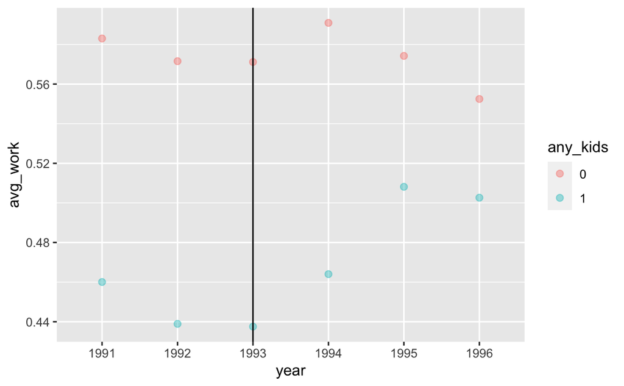

```r
#We need to transform any_kids and year variables into factor variables because aes requires it
#otherwise we kept having the "Continuous value supplied to discrete scale" error message
eitc_sum$any_kids <- as.factor(eitc_sum$any_kids)
eitc_sum$year <- as.factor(eitc_sum$year)
ggplot(eitc_sum, mapping = aes(x = year, y = avg_work, color = any_kids)) +
    geom_point(size = 2, alpha = 0.4) +
    geom_vline(xintercept = "1993")
```

We do notice a pre-treatment trend. The first three points follow a similar trend: in both cases, there is a first significant decrease between 1991 and 1992 and then a second very slight decrease between 1992 and 1993.  
**11.** Based on the following model, run a regression to find the diff-in-diff estimate of the effect of the EITC on employment (`work`).

$$\begin{equation}
\text { work }=\alpha+\beta \text { after_1993 }+\gamma \text { any_kids }+\delta \text { (after_1993 } \times \text { any_kids) }+ \epsilon
\end{equation}$$

```r
m3 <- lm(work ~ after_1993 + any_kids + after_1993*any_kids, data = eitc)
summary(m3)
```

```
Call:
lm(formula = work ~ after_1993 + any_kids + after_1993 * any_kids,
    data = eitc)

Residuals:
    Min      1Q  Median      3Q     Max
-0.5755 -0.4908  0.4245  0.5092  0.5540

Coefficients:
                     Estimate Std. Error t value Pr(>|t|)
(Intercept)          0.575460   0.008845  65.060  < 2e-16 ***
after_1993          -0.002074   0.012931  -0.160  0.87261
any_kids            -0.129498   0.011676 -11.091  < 2e-16 ***
after_1993:any_kids  0.046873   0.017158   2.732  0.00631 **
---
Signif. codes:  0 ‘***’ 0.001 ‘**’ 0.01 ‘*’ 0.05 ‘.’ 0.1 ‘ ’ 1

Residual standard error: 0.4967 on 13742 degrees of freedom
Multiple R-squared:  0.0126,    Adjusted R-squared:  0.01238
F-statistic: 58.45 on 3 and 13742 DF,  p-value: < 2.2e-16
```

**12.** What is the difference-in-difference estimate? Discuss the result.

The difference-in-difference estimate is `0.046873` (after_1993:any_kids’ row). It means that the EITC had a positive impact on the employment rate of women that can obtain the EITC: their employment rate increased by 4.6%. Also, the estimate is statistically significant (p-value < 0.01).

**13.** Run a new regression model with demographic controls. Eissa and Liebman used the following in their original study: non-labor income (family income minus personal earnings, or the `unearn` column), number of children, race, age, age squared, education, and education squared.

```r
#We just add the new variables to the previous model
m4 <- lm(work ~ after_1993 + any_kids + after_1993 * any_kids + unearn + children + nonwhite + age + age^2 +ed + ed^2, data = eitc)
summary(m4)
```

```
Call:
lm(formula = work ~ after_1993 + any_kids + after_1993 * any_kids +
    unearn + children + nonwhite + age + age^2 + ed + ed^2, data = eitc)

Residuals:
    Min      1Q  Median      3Q     Max
-0.7722 -0.4802  0.2608  0.4219  2.5109

Coefficients:
                      Estimate Std. Error t value Pr(>|t|)
(Intercept)          0.4683963  0.0246887  18.972  < 2e-16 ***
after_1993          -0.0071762  0.0123626  -0.580 0.561604
any_kids            -0.0151495  0.0146814  -1.032 0.302145
unearn              -0.0175575  0.0005764 -30.462  < 2e-16 ***
children            -0.0468754  0.0044945 -10.430  < 2e-16 ***
nonwhite            -0.0637299  0.0084998  -7.498 6.89e-14 ***
age                  0.0027485  0.0004227   6.503 8.17e-11 ***
ed                   0.0141295  0.0015733   8.981  < 2e-16 ***
after_1993:any_kids  0.0547243  0.0163990   3.337 0.000849 ***
---
Signif. codes:  0 ‘***’ 0.001 ‘**’ 0.01 ‘*’ 0.05 ‘.’ 0.1 ‘ ’ 1

Residual standard error: 0.4747 on 13737 degrees of freedom
Multiple R-squared:  0.09877,   Adjusted R-squared:  0.09825
F-statistic: 188.2 on 8 and 13737 DF,  p-value: < 2.2e-16
```

```r
stargazer(m4, type = "text")
```

```
===============================================
                        Dependent variable:
                    ---------------------------
                               work
-----------------------------------------------
after_1993                    -0.007
                              (0.012)

any_kids                      -0.015
                              (0.015)

unearn                       -0.018***
                              (0.001)

children                     -0.047***
                              (0.004)

nonwhite                     -0.064***
                              (0.008)

age                          0.003***
                             (0.0004)

ed                           0.014***
                              (0.002)

after_1993:any_kids          0.055***
                              (0.016)

Constant                     0.468***
                              (0.025)

-----------------------------------------------
Observations                  13,746
R2                             0.099
Adjusted R2                    0.098
Residual Std. Error     0.475 (df = 13737)
F Statistic         188.196*** (df = 8; 13737)
===============================================
Note:               *p<0.1; **p<0.05; ***p<0.01
```

**14.** Does the treatment effect change? Interpret these findings.

Yes, the treatment effect does change by controlling for the added variables : the difference-in-difference estimate is now `0.0547243` (`0.046873` in the previous question). It means that the added demographic characteristics have a significant effect on eligibility for EITC: they allow a fair comparaison between woman with similar characteristics.

**15.** Make two new binary indicator variables showing if the woman has one child or not and two children or not. Name them `one_kid` and `two_plus_kids`.

```r
eitc <- eitc %>%
  mutate(one_kid = ifelse(
    children == 1, 1, 0))
eitc <- eitc %>%
  mutate(two_plus_kids = ifelse(
    children == 2, 1, 0))
```

**16.** Rerun the regression model with all the demographic controls, but remove the `any_kids` and `any_kids * after_1993` terms and replace them with two new interaction terms: `one_kid * after_1993` and `two_plus_kids * after_1993`. For which group of women is the EITC treatment the strongest for ( *i.e.* which group sees the greatest change in employment)? Why do you think that is?

```r
#we add I() to isolate the contents of age² and ed². It allows them to work as if used outside of a formula
#rather than being treated as special formula operators. Thanks stackoverflow
m5 <- lm(work ~ after_1993 * one_kid + after_1993 * two_plus_kids + unearn + children + nonwhite + age + I(age^2) +ed + I(ed^2), data = eitc)
summary(m5)
```

```
Call:
lm(formula = work ~ after_1993 * one_kid + after_1993 * two_plus_kids +
    unearn + children + nonwhite + age + I(age^2) + ed + I(ed^2),
    data = eitc)

Residuals:
    Min      1Q  Median      3Q     Max
-0.7915 -0.4762  0.2442  0.4218  2.5031

Coefficients:
                           Estimate Std. Error t value Pr(>|t|)
(Intercept)               5.351e-02  5.997e-02   0.892  0.37224
after_1993                1.451e-02  1.043e-02   1.391  0.16418
one_kid                  -4.509e-03  1.371e-02  -0.329  0.74232
two_plus_kids            -2.945e-03  1.524e-02  -0.193  0.84680
unearn                   -1.775e-02  5.765e-04 -30.798  < 2e-16 ***
children                 -5.085e-02  3.264e-03 -15.577  < 2e-16 ***
nonwhite                 -6.254e-02  8.484e-03  -7.372 1.78e-13 ***
age                       2.984e-02  3.266e-03   9.137  < 2e-16 ***
I(age^2)                 -3.733e-04  4.492e-05  -8.310  < 2e-16 ***
ed                       -4.016e-03  5.955e-03  -0.674  0.50010
I(ed^2)                   1.416e-03  4.342e-04   3.261  0.00111 **
after_1993:one_kid        2.058e-02  2.010e-02   1.024  0.30604
after_1993:two_plus_kids  3.020e-02  2.205e-02   1.369  0.17089
---
Signif. codes:  0 ‘***’ 0.001 ‘**’ 0.01 ‘*’ 0.05 ‘.’ 0.1 ‘ ’ 1

Residual standard error: 0.4735 on 13733 degrees of freedom
Multiple R-squared:  0.1035,    Adjusted R-squared:  0.1027
F-statistic: 132.2 on 12 and 13733 DF,  p-value: < 2.2e-16
```

```r
stargazer(m5, type="text")
```

```
====================================================
                             Dependent variable:
                         ---------------------------
                                    work
----------------------------------------------------
after_1993                          0.015
                                   (0.010)

one_kid                            -0.005
                                   (0.014)

two_plus_kids                      -0.003
                                   (0.015)

unearn                            -0.018***
                                   (0.001)

children                          -0.051***
                                   (0.003)

nonwhite                          -0.063***
                                   (0.008)

age                               0.030***
                                   (0.003)

I(age2)                          -0.0004***
                                  (0.00004)

ed                                 -0.004
                                   (0.006)

I(ed2)                            0.001***
                                  (0.0004)

after_1993:one_kid                  0.021
                                   (0.020)

after_1993:two_plus_kids            0.030
                                   (0.022)

Constant                            0.054
                                   (0.060)

----------------------------------------------------
Observations                       13,746
R2                                  0.104
Adjusted R2                         0.103
Residual Std. Error          0.473 (df = 13733)
F Statistic              132.155*** (df = 12; 13733)
====================================================
Note:                    *p<0.1; **p<0.05; ***p<0.01
```

Create a new dataset that only includes data from 1991–1993. Create a new binary before/after indicator named `after_1991`. Use regression to find the diff-in-diff estimate of the EITC on `work`.

```r
year_target <- c("1991","1992","1993")
new_dataset <- eitc %>%
    filter(year %in% year_target)
```

```r
new_dataset <- new_dataset %>%
  mutate(after_1991 = ifelse( year > "1991", 1, 0))
```

```r
#we take back the previous model and replace after_1993 by the after_1991 dummy
m6 <- lm(work ~ after_1991 * one_kid + after_1991 * two_plus_kids + unearn + children + nonwhite + age + I(age^2) +ed + I(ed^2), data = new_dataset)
summary(m6)
```

```
Call:
lm(formula = work ~ after_1991 * one_kid + after_1991 * two_plus_kids +
    unearn + children + nonwhite + age + I(age^2) + ed + I(ed^2),
    data = new_dataset)

Residuals:
    Min      1Q  Median      3Q     Max
-0.8008 -0.4656  0.2161  0.4258  2.3524

Coefficients:
                           Estimate Std. Error t value Pr(>|t|)
(Intercept)               0.1075406  0.0828075   1.299   0.1941
after_1991               -0.0171627  0.0148130  -1.159   0.2466
one_kid                   0.0004473  0.0227701   0.020   0.9843
two_plus_kids             0.0009545  0.0258748   0.037   0.9706
unearn                   -0.0181970  0.0007972 -22.827  < 2e-16 ***
children                 -0.0600194  0.0044687 -13.431  < 2e-16 ***
nonwhite                 -0.0548905  0.0114318  -4.802 1.61e-06 ***
age                       0.0298942  0.0045042   6.637 3.43e-11 ***
I(age^2)                 -0.0003714  0.0000619  -6.000 2.07e-09 ***
ed                       -0.0182212  0.0080559  -2.262   0.0237 *
I(ed^2)                   0.0024167  0.0005890   4.103 4.12e-05 ***
after_1991:one_kid       -0.0070041  0.0283500  -0.247   0.8049
after_1991:two_plus_kids  0.0095066  0.0313977   0.303   0.7621
---
Signif. codes:  0 ‘***’ 0.001 ‘**’ 0.01 ‘*’ 0.05 ‘.’ 0.1 ‘ ’ 1

Residual standard error: 0.472 on 7388 degrees of freedom
Multiple R-squared:  0.1103,    Adjusted R-squared:  0.1088
F-statistic: 76.29 on 12 and 7388 DF,  p-value: < 2.2e-16
```

```r
stargazer(m6, type="text")
```

```
====================================================
                             Dependent variable:
                         ---------------------------
                                    work
----------------------------------------------------
after_1991                         -0.017
                                   (0.015)

one_kid                            0.0004
                                   (0.023)

two_plus_kids                       0.001
                                   (0.026)

unearn                            -0.018***
                                   (0.001)

children                          -0.060***
                                   (0.004)

nonwhite                          -0.055***
                                   (0.011)

age                               0.030***
                                   (0.005)

I(age2)                          -0.0004***
                                  (0.0001)

ed                                -0.018**
                                   (0.008)

I(ed2)                            0.002***
                                   (0.001)

after_1991:one_kid                 -0.007
                                   (0.028)

after_1991:two_plus_kids            0.010
                                   (0.031)

Constant                            0.108
                                   (0.083)

----------------------------------------------------
Observations                        7,401
R2                                  0.110
Adjusted R2                         0.109
Residual Std. Error           0.472 (df = 7388)
F Statistic               76.288*** (df = 12; 7388)
====================================================
Note:                    *p<0.1; **p<0.05; ***p<0.01
```

**18.** Is there a significant effect? What does this mean for pre-treatment trends?

No it is not significant (p-value > 0.1). The fact that we don’t get the same results before 1993 could mean that the employment increase after 1993 could be due to EITC expansion.